# An introduction to Bayesian statistics for palaeoclimatologists

Andrew C Parnell, Niamh Cahill, Michael Salter-Townshend

# Who was Bayes?

*An essay towards solving a problem on the doctrine of chances* (1763)

$$P(A|B) = \frac{P(B|A) P(A)}{P(B)}$$

# What is Bayes?

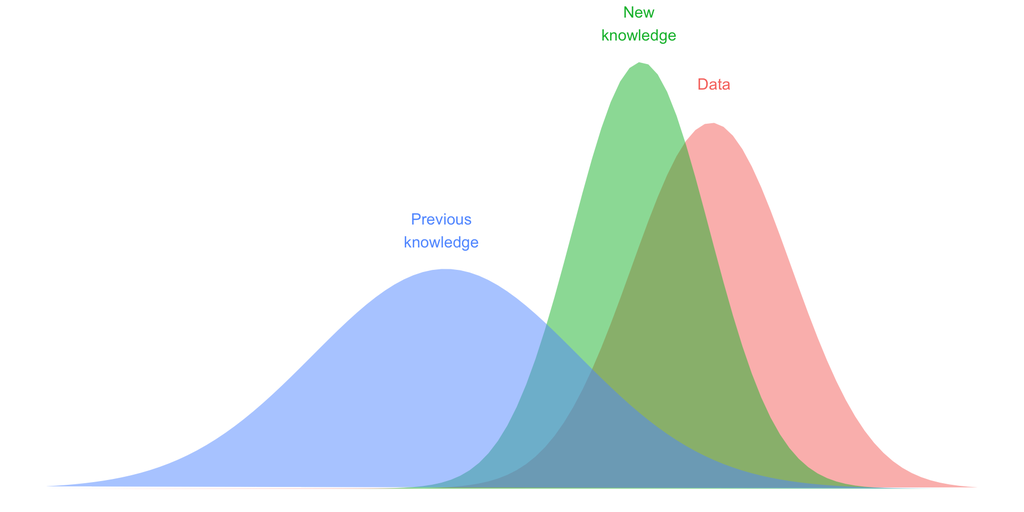

# How does it work?

1. Divide up your world into things you know (**data**) and things you don’t know (**parameters**)
2. Create a **generative model** that says what the data would look like if you knew what the parameters were
3. Calculate the **posterior** probability distribution to obtain our new knowledge using Bayes’ theorem (and a helpful R package or Bayesian statistician)

# How does this work for palaeoclimate reconstruction?

1. We know the ancient proxies and the modern proxy/climate relationship. These are our **data**. The ancient climate are our unknown **parameters**
2. We can build a generative model for how ancient pollen might form from ancient climate
3. We turn the Bayesian handle to produce a posterior probability distribution of ancient climate given ancient pollen

# Why is this better?

- **Because you get a probability distribution for your unknowns given what you know**
- **Because you can incorporate external information that you know about your system**
- **Because it avoids terrible $p$-values**

*A p-value, or statistical significance, does not measure the size of an effect or the importance of a result* - American Statistical Association 2017

# Ex 1: Kemp et al. 2013 QSR

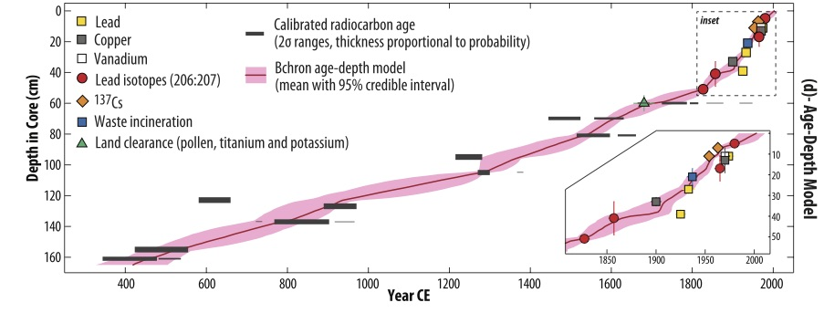

# Ex 2: Cahill et al. 2016 COTP

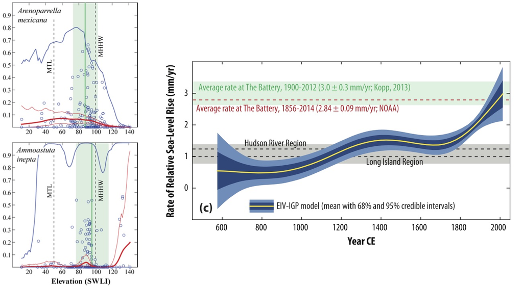

# A note on computation

- Most methods to compute the posterior distribution (the *new knowledge*) work via trial and error on the unknown parameters
- This means that rather than a single best value you get a *spreadsheet of values* that match the data

```
##   c(t_1) c(t_2) c(t_3)
## 1  0.527  0.452 -0.665
## 2  1.176  1.451 -0.527
## 3  0.619 -1.255  0.030
## 4 -0.631 -0.712 -0.264
## 5 -1.030 -0.831 -0.272
```

# The rest of this session

1. *Nils Weitzel*, Combining a proxy synthesis and climate simulations for spatial reconstructions of European climate using Bayesian filtering
2. *Lauren Gregoire*, Searching for the deglaciation: sampling spatio-temporal climate uncertainty for simulating ice sheet evolution
3. *Lambert Caron*, Quantifying the Information Content of Relative Sea-level and Geodetic Data for Constraint on North American GIA Models
4. *Erica Ashe*, Estimating global sea level over the late Holocene using a spatio-temporal empirical Bayesian hierarchical framework
5. *Marco Antonio Aquino Lopez*, Bayesian improvements to 210Pb dating